# Homework 2 Solutions

Matt Lukac

October 25, 2018

## Identifying Variables

In this study, we examine the effects a diet of enriched shrimp nauplii has on the size of zebrafish. We take the size to be defined in terms of the weight and standard length (SL) of the zebrafish. Let’s take a peak at the data.

```r
library(tidyverse)

zfish <- read_tsv(file = "zfish_diet_IA.tsv")
head(zfish)
```

```
## # A tibble: 6 x 4
##   Individual Diet        SL Weight
##        <int> <chr>    <dbl>  <dbl>
## 1          1 Control   3.58  0.554
## 2          2 Enriched  4.66  0.699
## 3          3 Enriched  4.5   0.644
## 4          4 Control   3.71  0.624
## 5          5 Control   4.36  0.688
## 6          6 Control   3.89  0.613
```

It looks like we have one categorical predictor variable, given by the diet, which is either `Control` or `Enriched`. We have two continuous response variables: standard length, and wet weight. Since length and weight of organisms are usually normally distributed, we should expect these data to be approximately normal.

## Data Exploration

To get an idea of the response variable’s distributions, we’ll glance at some boxplots.

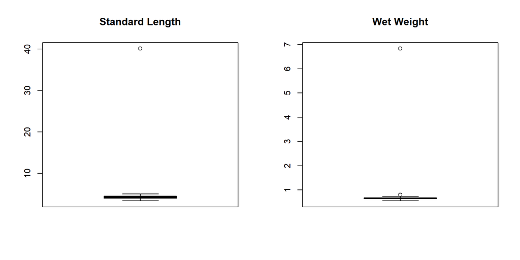

```r
par(mfrow=c(1,2))
boxplot(zfish$SL, main = 'Standard Length', col = 'red')
boxplot(zfish$Weight, main = 'Wet Weight', col = 'blue')
```

There are two outliers due to transcription errors, one in SL and one in Weight. They simply need to be divided by 10.

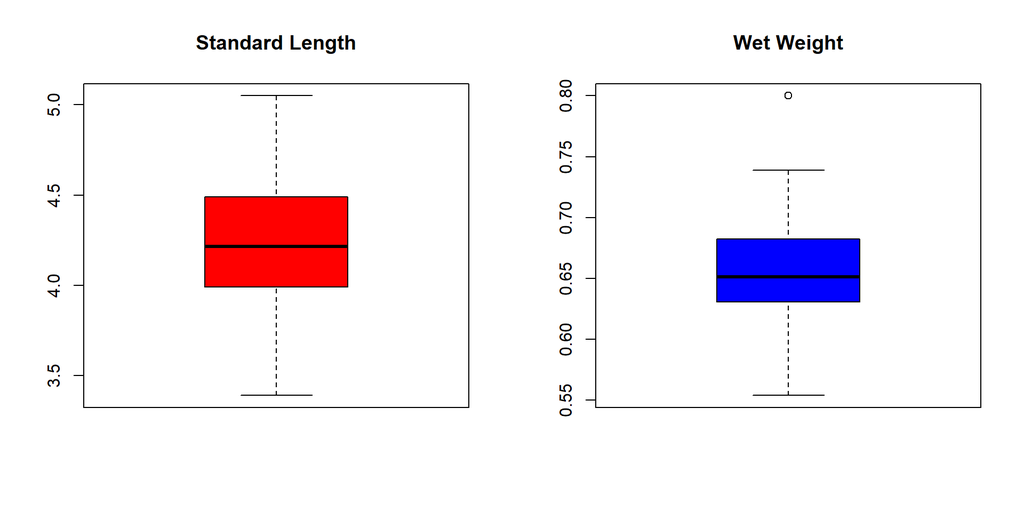

```r
zfish$SL[which.max(zfish$SL)] <- zfish$SL[which.max(zfish$SL)]/10
zfish$Weight[which.max(zfish$Weight)] <- zfish$Weight[which.max(zfish$Weight)]/10

#improved boxplots
par(mfrow=c(1,2))
boxplot(zfish$SL, main = 'Standard Length', col = 'red')
boxplot(zfish$Weight, main = 'Wet Weight', col = 'blue')
```

That looks much better. The below histograms give us a good look at the distributions for SL and Weight.

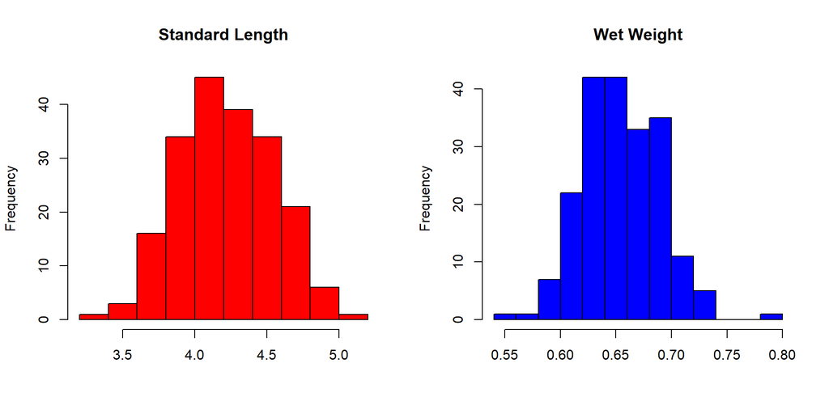

```r
par(mfrow=c(1,2))
hist(zfish$SL, main = 'Standard Length', col = 'red', xlab = "")
hist(zfish$Weight, main = 'Wet Weight', col = 'blue', xlab = "")
```

Fortunately both distributions appear approximately normal, which is an underlying assumption for the t-test we will perform momentarily. Now what about the distributions when we sort by diet?

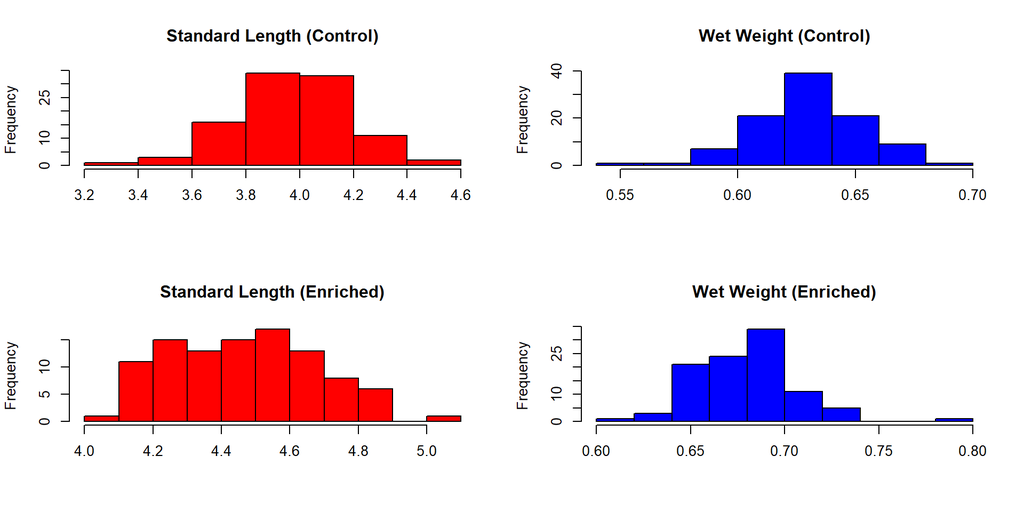

```r
zfish_control <- zfish %>%
  filter(Diet == "Control")
zfish_enriched <- zfish %>%
  filter(Diet == "Enriched")

par(mfrow=c(2,2))
hist(zfish_control$SL, main = 'Standard Length (Control)', col = 'red', xlab = "")
hist(zfish_control$Weight, main = 'Wet Weight (Control)', col = 'blue', xlab = "")
hist(zfish_enriched$SL, main = 'Standard Length (Enriched)', col = 'red', xlab = "")
hist(zfish_enriched$Weight, main = 'Wet Weight (Enriched)', col = 'blue', xlab = "")
```

Again, these distributions appear approximately normal, which is good. Let’s look at some summary statistics. To do this we will utilize `group_by` and `summarise`.

```r
sum_stats <- zfish %>% group_by(Diet) %>% summarise(SL_mean = mean(SL),
                                                    SL_sd = sd(SL),
                                                    SL_var = var(SL),
                                                    Weight_mean = mean(Weight),
                                                    Weight_sd = sd(Weight),
                                                    Weight_var = var(Weight))
head(sum_stats)
```

```
## # A tibble: 2 x 7
##   Diet     SL_mean SL_sd SL_var Weight_mean Weight_sd Weight_var
##   <chr>      <dbl> <dbl>  <dbl>       <dbl>     <dbl>      <dbl>
## 1 Control     3.98 0.210 0.0442       0.630    0.0230   0.000528
## 2 Enriched    4.47 0.212 0.0451       0.681    0.0271   0.000733
```

## Bivariate Plot

Here, we’ll take a look at how correlated the length and weight are. We should expect there to be a positive correlation since a longer body will weigh more than a shorter body of the same girth. Note the distinction of points from separate diets.

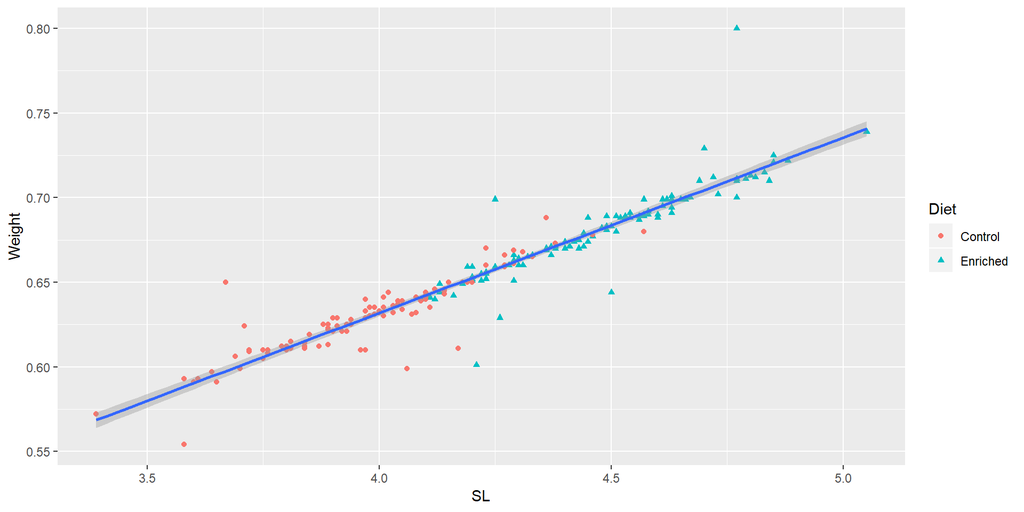

```r
library(ggplot2)
ggplot(data = zfish) +
  geom_point(mapping = aes(x = SL, y = Weight, color = Diet, shape = Diet), show.legend = T) +
  geom_smooth(mapping = aes(x = SL, y = Weight), method = 'lm')
```

## Diet Affects Length and Weight

There is no reason we should assume *a priori* that the enriched diet will affect the zebrafish size in a positive or negative fashion. As such, the alternative hypothesis is two sided in this study. That is, the enriched diet has some effect on the zebrafish size. Our null hypothesis is, of course, that the enriched diet has no effect on the size of the zebrafish.

More formally, let $\mu_{c,\text{W}}$ and $\mu_{e,\text{W}}$ denote the populations means for the weights of the control and enriched groups, respectively. Then we have the hypotheses
$$\begin{align*}
H_0\colon \mu_{c,\text{W}} - \mu_{e,\text{W}} &= 0\\
H_1\colon \mu_{c,\text{W}} - \mu_{e,\text{W}} &\neq 0.
\end{align*}$$

Similarly, let $\mu_{c,\text{SL}}$ and $\mu_{e,\text{SL}}$ denote the population means for the standard lengths of the control and enriched groups, respectively. Then we have the same hypotheses as above by simply replacing the ‘W’ subscripts with the ‘SL’ subscripts.

Based on group-wise distributions for both dependent variables, samples are approximately normal, and variances are similar in both groups. So it’s okay to use parametric t-test.

```r
#Two-tailed t-test (with Welch correction) for equal Standard Length between groups
test_length <- t.test(SL~Diet, data=zfish)
test_length
```

```
##
##  Welch Two Sample t-test
##
## data:  SL by Diet
## t = -16.438, df = 197.98, p-value < 2.2e-16
## alternative hypothesis: true difference in means is not equal to 0
## 95 percent confidence interval:
##  -0.5500172 -0.4321828
## sample estimates:
##  mean in group Control mean in group Enriched
##                 3.9826                 4.4737
```

```r
#Two-tailed t-test (with Welch correction) for equal Weight between groups
test_weight <- t.test(Weight~Diet, data=zfish)
test_weight
```

```
##
##  Welch Two Sample t-test
##
## data:  Weight by Diet
## t = -14.192, df = 192.91, p-value < 2.2e-16
## alternative hypothesis: true difference in means is not equal to 0
## 95 percent confidence interval:
##  -0.05740441 -0.04339559
## sample estimates:
##  mean in group Control mean in group Enriched
##                0.63028                0.68068
```

In the above results for the standard length, we can see the test returns a test statistic of -16.438 under 197.98 which gives a p-value of 7.41e-39. Thus the data give good evidence to conclude that diet does indeed affect the zebrafish standard length. In fact, the 95% confidence interval for the difference in mean lengths $\mu_{c,\text{SL}} - \mu_{e,\text{SL}}$ is -0.55, -0.432, so we conclude the enriched diet is likely to increase zebrafish length.

Similarly for the weight, the test returns a test statistic of -14.192 under 192.91 degrees of freedom, giving a p-value of 8.99e-32. Hence the data give good evidence to conclude the diet does indeed affect the zebrafish wet weight. Moreover, the 95% confidence interval for the difference in mean weights $\mu_{c,\text{W}} - \mu_{e,\text{W}}$ is -0.057, -0.043, so we conclude the enriched diet is likely to increase zebrafish weight.

The conclusion for the weight should not surprise us after we’ve looked at the conclusion for the length. From our bivariate plot we can see a clear strong positive correlation between the length and weight, so if the enriched diet tends to increase the length we should similarly expect it to increase the weight as well.